# GLM I - Binary Response

## Binary Data

## The example data

- Heart Disease Example

```r
summary(wcgs[, c("chd", "height", "cigs")])
```

|  | chd | height | cigs |
| --- | --- | --- | --- |
|  | no :2897 | Min. :60.00 | Min. : 0.0 |
|  | yes: 257 | 1st Qu.:68.00 | 1st Qu.: 0.0 |
|  | NA | Median :70.00 | Median : 0.0 |
|  | NA | Mean :69.78 | Mean :11.6 |
|  | NA | 3rd Qu.:72.00 | 3rd Qu.:20.0 |
|  | NA | Max. :78.00 | Max. :99.0 |

## Example Data

### Plot

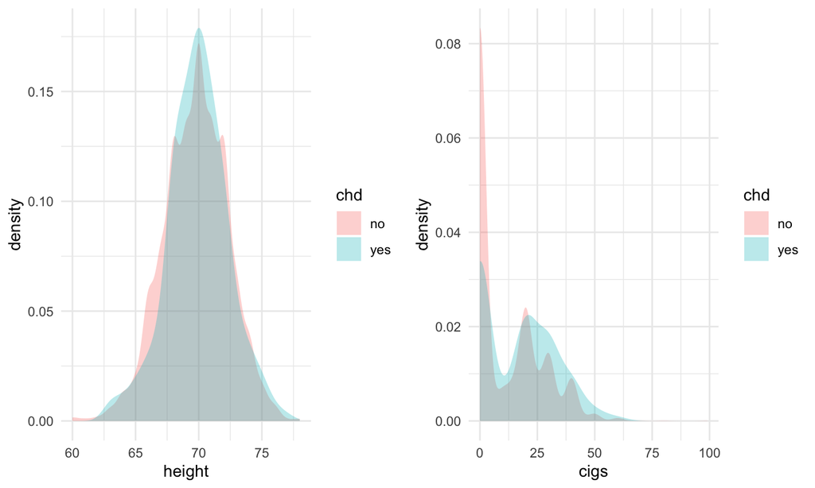

## Let’s create a linear model

```r
wcgs2 <- wcgs %>%
  mutate(chd = as.numeric(chd =='yes'))


lm(chd ~ height, data = wcgs2)
```

```
##
## Call:
## lm(formula = chd ~ height, data = wcgs2)
##
## Coefficients:
## (Intercept)       height
##    -0.06083      0.00204
```

## Let’s create a linear model

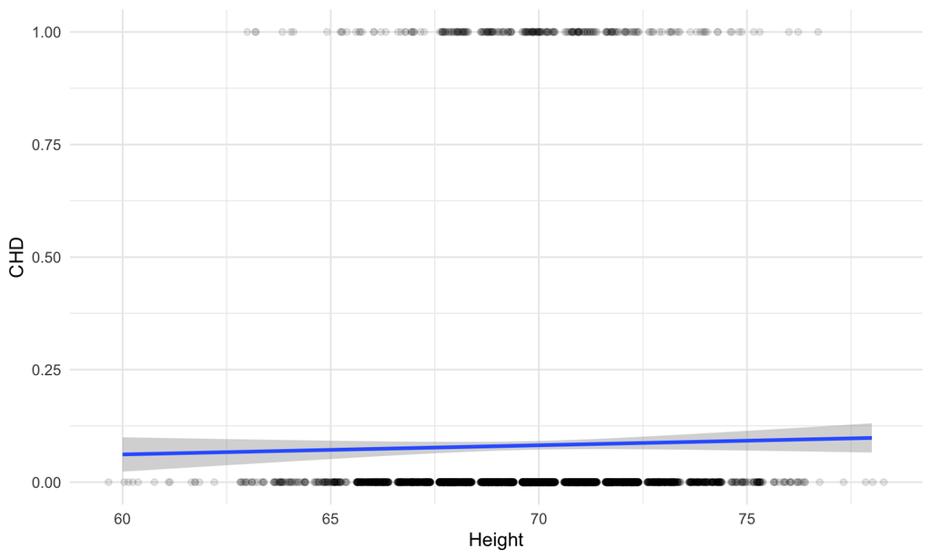

- What’s the issue with this model?

## Binary Regression:

- Assume response is distributed bernoulli \(B(p_i)\) for each \(i\) observation

\[ P(Y_i = y_i) = p_i^{y_i}(1-p_i)^{1-y_i} \] - Let’s construct a linear predictor with \(q\) terms

\[ \eta_i = \beta_0 + \beta_1x_{i1} + \cdots + \beta_qx_{iq} \] - before we had the \(\mu\) as our predictor in the normal density equation. What should we use now?

## We need a link function

- A link function is often used to transform the variable of interest (in this case \(p_i\)) to a reasonable scale for the linear predictor
- Options
  - Logit: \(\eta = log(p/(1-p))\)
  - Probit: \(\eta = \Phi^{-1}(p)\) where \(\Phi\) is the normal cumulative distribution
  - Complementary log-log: \(\eta = log(-log(1-p))\)

## Link function graphs

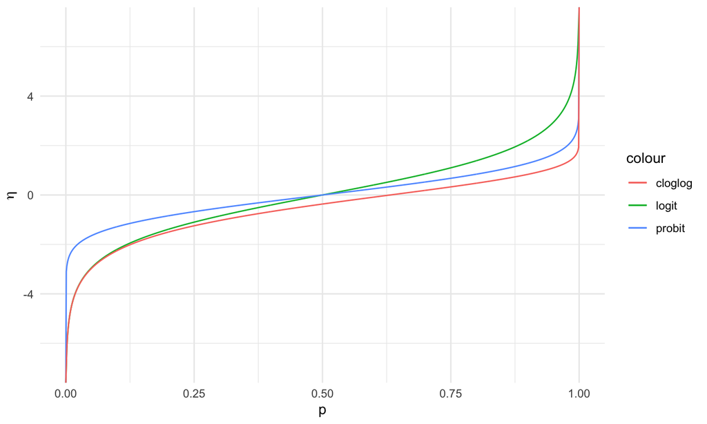

## What tools do we use to solve this?

- MLE!
- Example with logistic function

\[ p =\frac{e^{\eta}}{e^{\eta} + 1} \]

## Run it in R

```r
logitmod <- glm(chd ~ height, family = binomial(link = "logit"), data = wcgs)
summary(logitmod)
```

```
##
## Call:
## glm(formula = chd ~ height, family = binomial(link = "logit"),
##     data = wcgs)
##
## Deviance Residuals:
##     Min       1Q   Median       3Q      Max
## -0.4587  -0.4186  -0.4131  -0.4024   2.3157
##
## Coefficients:
##             Estimate Std. Error z value Pr(>|z|)
## (Intercept) -4.33732    1.81231  -2.393   0.0167 *
## height       0.02742    0.02590   1.058   0.2899
## ---
## Signif. codes:  0 '***' 0.001 '**' 0.01 '*' 0.05 '.' 0.1 ' ' 1
##
## (Dispersion parameter for binomial family taken to be 1)
##
##     Null deviance: 1781.2  on 3153  degrees of freedom
## Residual deviance: 1780.1  on 3152  degrees of freedom
## AIC: 1784.1
##
## Number of Fisher Scoring iterations: 5
```

## Compare links

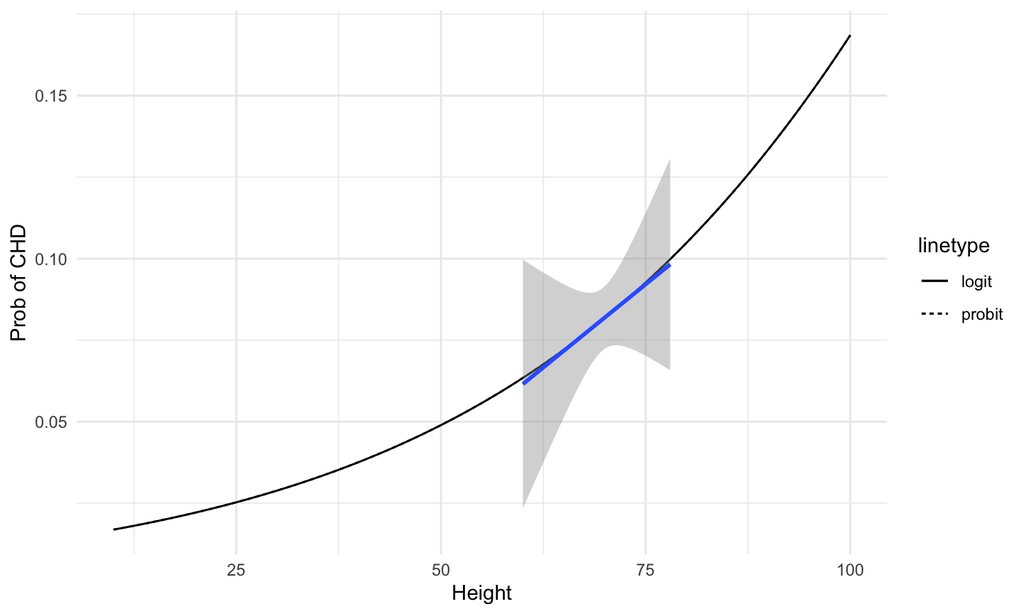

## Fit the full model

```
##
## Call:
## glm(formula = chd ~ height + cigs, family = binomial, data = wcgs)
##
## Deviance Residuals:
##     Min       1Q   Median       3Q      Max
## -1.0041  -0.4425  -0.3630  -0.3499   2.4357
##
## Coefficients:
##             Estimate Std. Error z value Pr(>|z|)
## (Intercept) -4.50161    1.84186  -2.444   0.0145 *
## height       0.02521    0.02633   0.957   0.3383
## cigs         0.02313    0.00404   5.724 1.04e-08 ***
## ---
## Signif. codes:  0 '***' 0.001 '**' 0.01 '*' 0.05 '.' 0.1 ' ' 1
##
## (Dispersion parameter for binomial family taken to be 1)
##
##     Null deviance: 1781.2  on 3153  degrees of freedom
## Residual deviance: 1749.0  on 3151  degrees of freedom
## AIC: 1755
##
## Number of Fisher Scoring iterations: 5
```

## How do we create predictions?

```r
coef(lmod)
```

```
## (Intercept)      height        cigs
## -4.50161397  0.02520779  0.02312740
```

```r
ilogit <- function(odds){
  exp(odds)/(exp(odds) + 1)
}

eta <- -4.50161397  + .02520779 * 50 + 10 * 0.02312740

ilogit(eta)
```

```
## [1] 0.04697836
```

```r
predict(lmod, data.frame(height = 50, cigs = 10), type = "response")
```

```
##          1
## 0.04697836
```

## Interperting Odds

\[ \frac{p}{1-p} = o \\ p = \frac{o}{1+o} \]

- unbounded \((0, \infty)\)
- log odds \((-\infty, \infty)\)

## Odds in regression

\[ log(\frac{p}{1-p}) = \beta_0 + \beta_1x_1 \\ odds = e^{\beta_0}e^{\beta_1x_1} \]

- this only applies to logit, hard to explain with probit, cloglog

```r
exp(coef(lmod))
```

```
## (Intercept)      height        cigs
##  0.01109108  1.02552819  1.02339691
```

- We can say that the odds of heart disease increase by 2.6% with each additional inch in height and by 2.3% with each additional cigarette smoked per day

## Odds

- let’s say \(x_1\) is a dummy variable (1 or 0)

\[ odds_1 = e^{\beta_0}e^{\beta_1} \\ odds_0 = e^{\beta_0} \]

- odds ratio

\[ \frac{odds_1}{odds_0} = e^{\beta_1} \]

## Relative Risk

```r
# 20 cigs, 68"
ilogit(sum(coef(lmod) * c(1,68, 20)))
```

```
## [1] 0.08907868
```

```r
# 20 cigs, 68"
ilogit(sum(coef(lmod) * c(1,68, 0)))
```

```
## [1] 0.05800425
```

- relative risk

```r
.089/.058
```

```
## [1] 1.534483
```

## Inference

## Likelihood Ratio

- \(L_L\) is a larger model, \(L_S\) is a smaller model

\[ 2log\frac{L_L}{L_S} \] - use saturated model where L_L fits the data perfectly so \(L_L\) = 0.

\[ \begin{align} D &= -2 \sum_{i=1}^n\hat p_i logit(\hat p_i) + log(1 - \hat p_i) \\ & = -2\sum_{i=1}^n{y_i log(\hat p_i) + (1 - y_i) log(1 - \hat p_i)} \end{align} \]

## Deviance

```
##
## Call:
## glm(formula = chd ~ height + cigs, family = binomial, data = wcgs)
##
## Deviance Residuals:
##     Min       1Q   Median       3Q      Max
## -1.0041  -0.4425  -0.3630  -0.3499   2.4357
##
## Coefficients:
##             Estimate Std. Error z value Pr(>|z|)
## (Intercept) -4.50161    1.84186  -2.444   0.0145 *
## height       0.02521    0.02633   0.957   0.3383
## cigs         0.02313    0.00404   5.724 1.04e-08 ***
## ---
## Signif. codes:  0 '***' 0.001 '**' 0.01 '*' 0.05 '.' 0.1 ' ' 1
##
## (Dispersion parameter for binomial family taken to be 1)
##
##     Null deviance: 1781.2  on 3153  degrees of freedom
## Residual deviance: 1749.0  on 3151  degrees of freedom
## AIC: 1755
##
## Number of Fisher Scoring iterations: 5
```

## Deviance

```r
p_hat <- fitted.values(lmod)

dev_res <- -2*sum(p_hat*logit(p_hat) + log(1-p_hat))

null_mod <- update(lmod, formula. = . ~ 1)
p_hat_null <- fitted.values(null_mod)
dev_null <- -2*sum(p_hat_null*logit(p_hat_null) + log(1-p_hat_null))

dev_res
```

```
## [1] 1749.049
```

```r
dev_null
```

```
## [1] 1781.244
```

## Compare two models

- degrees of freedom is the difference in df between the two models

```r
1 - pchisq(dev_null - dev_res, 2)
```

```
## [1] 1.02106e-07
```

- this suggests that the 2 variables we included are ‘useful’

## Look at a single variable

```r
lmodc <- glm(chd ~ cigs, family = binomial, wcgs)
anova(lmodc,lmod, test="Chi")
```

| Resid. Df | Resid. Dev | Df | Deviance | Pr(>Chi) |
| --- | --- | --- | --- | --- |
| 3152 | 1749.969 | NA | NA | NA |
| 3151 | 1749.049 | 1 | 0.9202473 | 0.3374101 |

## Confidence Interval

\[ \hat \beta_i \pm z^{\alpha/2}se(\hat \beta_i) \] For \(\beta_1\) (height)

```r
exp(0.02521 + c(-1,1) * 1.96 * 0.02633)
```

```
## [1] 0.9739486 1.0798442
```

```r
confint(lmod)
```

|  | 2.5 % | 97.5 % |
| --- | --- | --- |
| (Intercept) | -8.1347547 | -0.9129702 |
| height | -0.0261990 | 0.0770283 |
| cigs | 0.0151495 | 0.0310053 |

- liklihood is better

## Residuals

```r
pred_prob <- predict(lmod, type="response")
raw_res <- as.numeric((wcgs$chd ==  "yes")) - pred_prob
raw_res <- residuals(lmod, type = "response")
```

## Residuals’ Variance

- Variance is not constant (binary variance = p(1-p))
- use deviance residual instead

\[ r_i = sign(y_i - \hat p_i)\sqrt{r_i^2} \]

- The deviance residuals are not constrained to have mean zero so the mean level in the plot is not of interest.

```r
wcgs2 <- wcgs2 %>%
  mutate(residuals=residuals(lmod), linpred=predict(lmod))
```

## Plots of residuals

- Use smoothing instead of binning that’s in the book

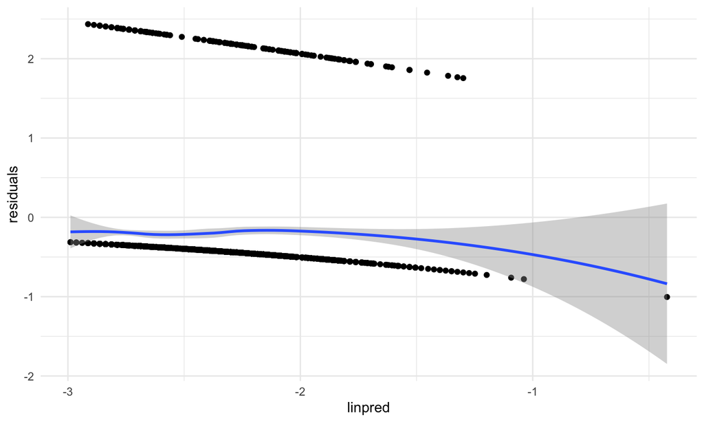

## Plots of residuals

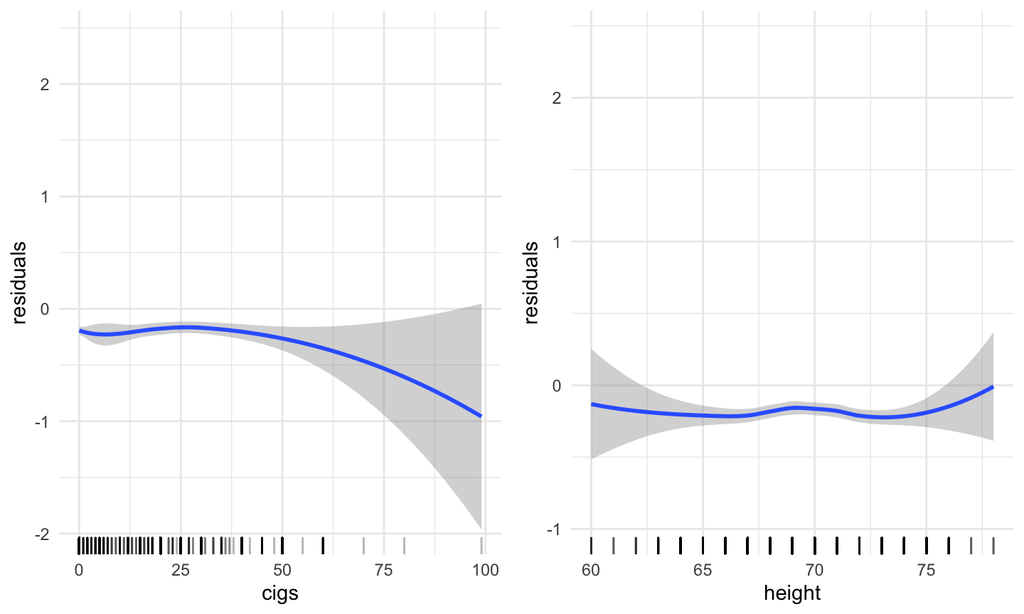

## Leverage

```r
wcgs2 %>%
  mutate(lev = hatvalues(lmod)) %>%
  arrange(-lev) %>%
  dplyr::select(height, cigs, lev)
```

| height | cigs | lev |
| --- | --- | --- |
| 71 | 99 | 0.0280034 |
| 64 | 80 | 0.0187294 |
| 76 | 60 | 0.0107423 |
| 71 | 70 | 0.0098510 |
| 74 | 60 | 0.0080759 |
| 66 | 60 | 0.0072673 |
| 73 | 60 | 0.0071473 |
| 67 | 60 | 0.0066109 |
| 72 | 60 | 0.0064751 |
| 72 | 60 | 0.0064751 |
| 74 | 55 | 0.0064741 |
| 60 | 30 | 0.0063419 |
| 75 | 50 | 0.0061798 |
| 64 | 50 | 0.0061661 |
| 68 | 60 | 0.0061509 |
| 68 | 60 | 0.0061509 |
| 71 | 60 | 0.0060494 |
| 71 | 60 | 0.0060494 |
| 62 | 40 | 0.0060221 |
| 69 | 60 | 0.0058973 |
| 70 | 60 | 0.0058602 |
| 70 | 60 | 0.0058602 |
| 74 | 50 | 0.0051461 |
| 66 | 50 | 0.0045425 |
| 73 | 50 | 0.0043484 |
| 73 | 50 | 0.0043484 |
| 73 | 50 | 0.0043484 |
| 73 | 50 | 0.0043484 |
| 73 | 50 | 0.0043484 |
| 65 | 45 | 0.0042372 |

[output cut: 3124 more lines]

## Model Selection

\[ AIC = -2log \space L + 2q \]

```
## Start:  AIC=1591.21
## chd ~ age + height + weight + bmi + sdp + dbp + chol + dibep +
##     cigs + arcus
##
##          Df Deviance    AIC
## - dbp     1   1569.2 1589.2
## - weight  1   1569.3 1589.3
## - bmi     1   1569.5 1589.5
## - height  1   1569.5 1589.5
## <none>        1569.2 1591.2
## - arcus   1   1571.3 1591.3
## - sdp     1   1577.0 1597.0
## - dibep   1   1590.5 1610.5
## - cigs    1   1592.2 1612.2
## - age     1   1593.8 1613.8
## - chol    1   1620.0 1640.0
##
## Step:  AIC=1589.22
## chd ~ age + height + weight + bmi + sdp + chol + dibep + cigs +
##     arcus
##
##          Df Deviance    AIC
## - weight  1   1569.3 1587.3
## - bmi     1   1569.5 1587.5
## - height  1   1569.5 1587.5
## <none>        1569.2 1589.2
## - arcus   1   1571.3 1589.3
## - sdp     1   1586.5 1604.5
## - dibep   1   1590.5 1608.5
## - cigs    1   1592.7 1610.7
## - age     1   1593.8 1611.8
## - chol    1   1620.0 1638.0
##
## Step:  AIC=1587.33
## chd ~ age + height + bmi + sdp + chol + dibep + cigs + arcus
##
##          Df Deviance    AIC
## <none>        1569.3 1587.3
## - arcus   1   1571.5 1587.5
## - height  1   1572.6 1588.6
## - bmi     1   1574.4 1590.4
## - sdp     1   1586.6 1602.6
## - dibep   1   1590.7 1606.7
## - cigs    1   1592.8 1608.8
## - age     1   1593.9 1609.9
## - chol    1   1620.0 1636.0
```

## Resulting Model

- This is ok if your goal is *prediction*

```
##
## Call:
## glm(formula = chd ~ age + height + bmi + sdp + chol + dibep +
##     cigs + arcus, family = binomial, data = wcgs2)
##
## Deviance Residuals:
##     Min       1Q   Median       3Q      Max
## -1.3225  -0.4352  -0.3118  -0.2199   2.8517
##
## Coefficients:
##                Estimate Std. Error z value Pr(>|z|)
## (Intercept)  -15.957599   2.286076  -6.980 2.94e-12 ***
## age            0.061590   0.012397   4.968 6.76e-07 ***
## height         0.050161   0.027824   1.803   0.0714 .
## bmi            0.060385   0.026599   2.270   0.0232 *
## sdp            0.017728   0.004155   4.267 1.98e-05 ***
## chol           0.010709   0.001529   7.006 2.45e-12 ***
## dibepB         0.657616   0.145898   4.507 6.56e-06 ***
## cigs           0.021041   0.004262   4.936 7.96e-07 ***
## arcuspresent   0.210998   0.143718   1.468   0.1421
## ---
## Signif. codes:  0 '***' 0.001 '**' 0.01 '*' 0.05 '.' 0.1 ' ' 1
##
## (Dispersion parameter for binomial family taken to be 1)
##
##     Null deviance: 1769.2  on 3139  degrees of freedom
## Residual deviance: 1569.3  on 3131  degrees of freedom
##   (14 observations deleted due to missingness)
## AIC: 1587.3
##
## Number of Fisher Scoring iterations: 6
```

## But what if you want inference?

- just cause a factor is dropped from the model doesn’t mean it may not influence outcome
- dbp was dropped from the model but that doesn’t mean it doesn’t influence the outcome

```
##
## Call:
## glm(formula = chd ~ dbp, family = binomial, data = wcgs2)
##
## Deviance Residuals:
##     Min       1Q   Median       3Q      Max
## -1.0988  -0.4298  -0.3902  -0.3541   2.4976
##
## Coefficients:
##              Estimate Std. Error z value Pr(>|z|)
## (Intercept) -5.221713   0.511646 -10.206  < 2e-16 ***
## dbp          0.033560   0.005981   5.611 2.01e-08 ***
## ---
## Signif. codes:  0 '***' 0.001 '**' 0.01 '*' 0.05 '.' 0.1 ' ' 1
##
## (Dispersion parameter for binomial family taken to be 1)
##
##     Null deviance: 1781.2  on 3153  degrees of freedom
## Residual deviance: 1751.7  on 3152  degrees of freedom
## AIC: 1755.7
##
## Number of Fisher Scoring iterations: 5
```

## Goodness of Fit

## Does a model fit?

- I don’t think this is a particularily useful question
- I’ve never come across a problem where a model doesn’t fit at all

## Calibration Curve

- the book shows a binned version (figure 2.9)

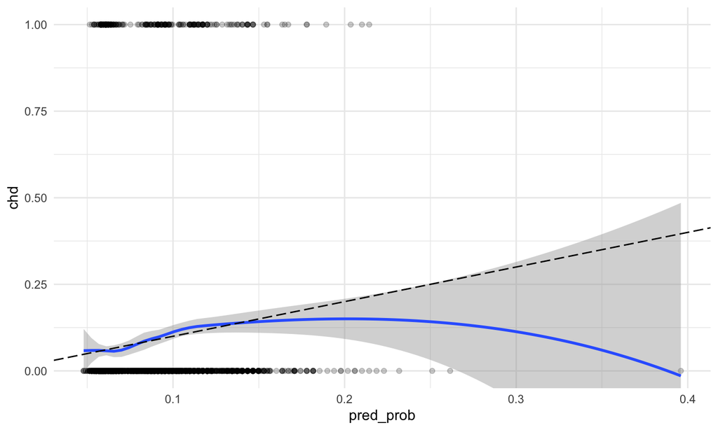

## Scoring

- Brier Score

\[ \frac{1}{n}\sum_{i=1}^n(\hat p_i - y_i)^2 \] - logarithmic scoring

\[ \sum y log(\hat p) + (1-y) log(1 - \hat p) \]

## Confusion Matrix

```r
tabl <- wcgs %>%
  filter(complete.cases(.)) %>%
  mutate(predout = ifelse(fitted.values(lmodr) > .5, "yes", "no")) %>%
  xtabs(~chd + predout, .)

tabl
```

| chd/predout | no | yes |
| --- | --- | --- |
| no | 2882 | 3 |
| yes | 253 | 2 |

- Accuracy =

```r
(2882+2)/(2882+3+253+2)
```

```
## [1] 0.9184713
```

## Specificity and Sensitivity

Specificity (for those the don’t have the diease how many were predicted to not have it) (chd = no group)

| chd/predout | no | yes |
| --- | --- | --- |
| no | 2882 | 3 |
| yes | 253 | 2 |

```r
2882/(2882 + 3)
```

```
## [1] 0.9989601
```

Sensitivity (for those that have disease how many were correctly identified?) (chd = yes)

```
## [1] 0.007843137
```

## PPV and NPV

| chd/predout | no | yes |
| --- | --- | --- |
| no | 2882 | 3 |
| yes | 253 | 2 |

- It may be more reasonable to ask: What’s the probability that I have the disease if I test positive?

PPV

```
## [1] 0.4
```

NPV

```
## [1] 0.9192982
```

## Vary the cutoff

```r
wcgsm <- wcgs2 %>%
  filter(complete.cases(.)) %>%
  mutate(predprob = predict(lmodr, .,type = "response"))


thresh <- seq(0.01,0.5,0.01)
Sensitivity <- numeric(length(thresh))
Specificity <- numeric(length(thresh))
PPV <- numeric(length(thresh))
NPV <- numeric(length(thresh))
F1 <- numeric(length(thresh))
for(j in seq(along=thresh)){
  pp <- ifelse(wcgsm$predprob < thresh[j],"no","yes")
  xx <- xtabs( ~ chd + pp, wcgsm)
  Specificity[j] <- xx[1,1]/(xx[1,1]+xx[1,2])
  Sensitivity[j] <- xx[2,2]/(xx[2,1]+xx[2,2])
  PPV[j] <- xx[2,2]/(xx[1,2] + xx[2,2])
  NPV[j] <- xx[1,1]/(xx[2,1] + xx[1, 1])
  F1[j] <-  xx[2,2]/(xx[2,2] + 1/2*(xx[2,1] + xx[1,2]))
}
full_df <- data.frame(
  thresh = thresh,
  sens = Sensitivity,
  spec = Specificity,
  PPV = PPV,
  NPV = NPV,
  F1 = F1
)
full_df$best <- NA
full_df$best[which.max(F1)] <- "Best"
best_thresh <- thresh[which.max(F1)]
```

## Sensitivity vs Specificity

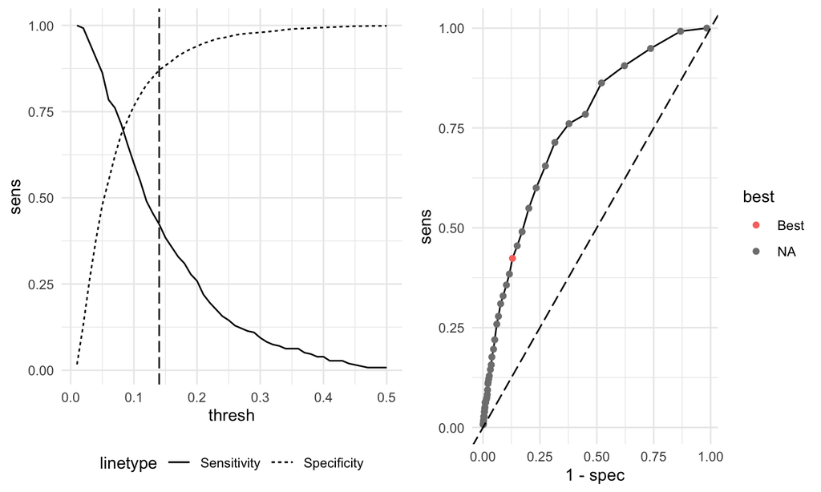

## NPV and PPV

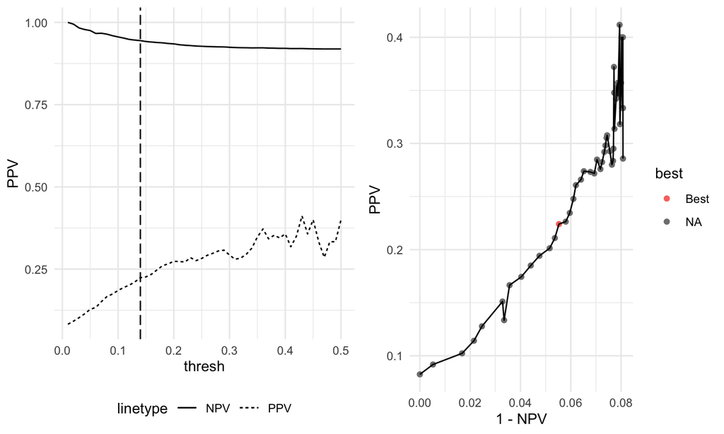

## Not covered

- \(R^2\)
- Estimation issues

## Lab with `pima` dataset (question 3 of excercise)

|  | pregnant | glucose | diastolic | triceps | insulin | bmi | diabetes | age | test |
| --- | --- | --- | --- | --- | --- | --- | --- | --- | --- |
|  | Min. : 0.000 | Min. : 0.0 | Min. : 0.00 | Min. : 0.00 | Min. : 0.0 | Min. : 0.00 | Min. :0.0780 | Min. :21.00 | Min. :0.000 |
|  | 1st Qu.: 1.000 | 1st Qu.: 99.0 | 1st Qu.: 62.00 | 1st Qu.: 0.00 | 1st Qu.: 0.0 | 1st Qu.:27.30 | 1st Qu.:0.2437 | 1st Qu.:24.00 | 1st Qu.:0.000 |
|  | Median : 3.000 | Median :117.0 | Median : 72.00 | Median :23.00 | Median : 30.5 | Median :32.00 | Median :0.3725 | Median :29.00 | Median :0.000 |
|  | Mean : 3.845 | Mean :120.9 | Mean : 69.11 | Mean :20.54 | Mean : 79.8 | Mean :31.99 | Mean :0.4719 | Mean :33.24 | Mean :0.349 |
|  | 3rd Qu.: 6.000 | 3rd Qu.:140.2 | 3rd Qu.: 80.00 | 3rd Qu.:32.00 | 3rd Qu.:127.2 | 3rd Qu.:36.60 | 3rd Qu.:0.6262 | 3rd Qu.:41.00 | 3rd Qu.:1.000 |
|  | Max. :17.000 | Max. :199.0 | Max. :122.00 | Max. :99.00 | Max. :846.0 | Max. :67.10 | Max. :2.4200 | Max. :81.00 | Max. :1.000 |

```
##
## Call:
## glm(formula = cbind(test, 1 - test) ~ ., family = "binomial",
##     data = pima)
##
## Deviance Residuals:
##     Min       1Q   Median       3Q      Max
## -2.5566  -0.7274  -0.4159   0.7267   2.9297
##
## Coefficients:
##               Estimate Std. Error z value Pr(>|z|)
## (Intercept) -8.4046964  0.7166359 -11.728  < 2e-16 ***
## pregnant     0.1231823  0.0320776   3.840 0.000123 ***
## glucose      0.0351637  0.0037087   9.481  < 2e-16 ***
## diastolic   -0.0132955  0.0052336  -2.540 0.011072 *
## triceps      0.0006190  0.0068994   0.090 0.928515
## insulin     -0.0011917  0.0009012  -1.322 0.186065
## bmi          0.0897010  0.0150876   5.945 2.76e-09 ***
## diabetes     0.9451797  0.2991475   3.160 0.001580 **
## age          0.0148690  0.0093348   1.593 0.111192
## ---
## Signif. codes:  0 '***' 0.001 '**' 0.01 '*' 0.05 '.' 0.1 ' ' 1
##
## (Dispersion parameter for binomial family taken to be 1)
##
##     Null deviance: 993.48  on 767  degrees of freedom
## Residual deviance: 723.45  on 759  degrees of freedom
## AIC: 741.45
##
## Number of Fisher Scoring iterations: 5
```

```
## [1] 0.8185642
```

|  | pregnant | glucose | diastolic | triceps | insulin | bmi | diabetes | age | test |
| --- | --- | --- | --- | --- | --- | --- | --- | --- | --- |
| 567 | 1 | 99 | 72 | 30 | 18 | 38.6 | 0.412 | 21 | 0 |
| 672 | 1 | 99 | 58 | 10 | 0 | 25.4 | 0.551 | 21 | 0 |